# Project 2 : Noshowappointments DataSet Analysis

- Introduction
- Data Wrangling
- Exploratory Data Analysis
- Research Question 1
- Research Question 2
- Research Question 3
- Research Question 4
- Research Question 5
- Research Question 6
- Conclusions

# Introduction

## Selected dataset: [noshowappointments](https://d17h27t6h515a5.cloudfront.net/topher/2017/October/59dd2e9a_noshowappointments-kagglev2-may-2016/noshowappointments-kagglev2-may-2016.csv)

**Description**: This dataset collects information from 100k medical appointments in Brazil and is focused on the question of whether or not patients show up for their appointment. A number of characteristics about the patient are included in each row.

**The Questions posed:**

- **`What is the overall percentage of showing up on the appointment day with a relation to who didnt?`**
- **`Is the Gender associated with patient decision?`**
- **`Does the location of the hospital affect the patient decision of coming to it on the scheduled date?`**
- **`Does the age of the patient have any correlation to their decision?`**
- **`Does a certain feature (Scholarship , SMS-received) have an influence on the patient decision?`**
- **`How is the patient decision does gets affected by their current health status? (any type of illness)`**

```python
# Use this cell to set up import statements for all of the packages that you
#   plan to use.
# Remember to include a 'magic word' so that your visualizations are plotted
#   inline with the notebook. See this page for more:
#   http://ipython.readthedocs.io/en/stable/interactive/magics.html
import pandas as pd
import numpy as np
import matplotlib.pyplot as plt
import seaborn as sns
%matplotlib inline
```

## Data Wrangling

```python
# Load your data and print out a few lines. Perform operations to inspect data
#   types and look for instances of missing or possibly errant data.
data = pd.read_csv('noshowappointments-2016.csv')
data
```

|  | PatientId | AppointmentID | Gender | ScheduledDay | AppointmentDay | Age | Neighbourhood | Scholarship | Hipertension | Diabetes | Alcoholism | Handcap | SMS_received | No-show |
| --- | --- | --- | --- | --- | --- | --- | --- | --- | --- | --- | --- | --- | --- | --- |
| 0 | 2.987250e+13 | 5642903 | F | 2016-04-29T18:38:08Z | 2016-04-29T00:00:00Z | 62 | JARDIM DA PENHA | 0 | 1 | 0 | 0 | 0 | 0 | No |
| 1 | 5.589978e+14 | 5642503 | M | 2016-04-29T16:08:27Z | 2016-04-29T00:00:00Z | 56 | JARDIM DA PENHA | 0 | 0 | 0 | 0 | 0 | 0 | No |
| 2 | 4.262962e+12 | 5642549 | F | 2016-04-29T16:19:04Z | 2016-04-29T00:00:00Z | 62 | MATA DA PRAIA | 0 | 0 | 0 | 0 | 0 | 0 | No |
| 3 | 8.679512e+11 | 5642828 | F | 2016-04-29T17:29:31Z | 2016-04-29T00:00:00Z | 8 | PONTAL DE CAMBURI | 0 | 0 | 0 | 0 | 0 | 0 | No |
| 4 | 8.841186e+12 | 5642494 | F | 2016-04-29T16:07:23Z | 2016-04-29T00:00:00Z | 56 | JARDIM DA PENHA | 0 | 1 | 1 | 0 | 0 | 0 | No |
| ... | ... | ... | ... | ... | ... | ... | ... | ... | ... | ... | ... | ... | ... | ... |
| 110522 | 2.572134e+12 | 5651768 | F | 2016-05-03T09:15:35Z | 2016-06-07T00:00:00Z | 56 | MARIA ORTIZ | 0 | 0 | 0 | 0 | 0 | 1 | No |
| 110523 | 3.596266e+12 | 5650093 | F | 2016-05-03T07:27:33Z | 2016-06-07T00:00:00Z | 51 | MARIA ORTIZ | 0 | 0 | 0 | 0 | 0 | 1 | No |
| 110524 | 1.557663e+13 | 5630692 | F | 2016-04-27T16:03:52Z | 2016-06-07T00:00:00Z | 21 | MARIA ORTIZ | 0 | 0 | 0 | 0 | 0 | 1 | No |
| 110525 | 9.213493e+13 | 5630323 | F | 2016-04-27T15:09:23Z | 2016-06-07T00:00:00Z | 38 | MARIA ORTIZ | 0 | 0 | 0 | 0 | 0 | 1 | No |
| 110526 | 3.775115e+14 | 5629448 | F | 2016-04-27T13:30:56Z | 2016-06-07T00:00:00Z | 54 | MARIA ORTIZ | 0 | 0 | 0 | 0 | 0 | 1 | No |

110527 rows × 14 columns

```python
data.shape
```

```
(110527, 14)
```

## Assessing Data

- 1st-Checking if there is any Duplicated or Incorrect Data and Renaming & fixing columns

```python
#Checking Duplication of the Dataset.
sum(data.duplicated())
```

```
0
```

```python
#Checking Duplication for Patient ID.
sum(data.PatientId.duplicated())
#there are some patients who made more than 1 Appointment.
```

```
48228
```

```python
#Checking Duplication for Appointment ID.
sum(data.AppointmentID.duplicated())
```

```
0
```

```python
#Renaming Columns to fix & make the data have a more clear names.
data.columns = ['PatientID', 'AppointmentID', 'Gender', 'ScheduledDay',
       'AppointmentDay', 'Age', 'Neighbourhood', 'Scholarship', 'Hypertension',
       'Diabetes', 'Alcoholism', 'Handicap', 'SMS_received', 'Attendance']
```

```python
data.info()
```

```
<class 'pandas.core.frame.DataFrame'>
RangeIndex: 110527 entries, 0 to 110526
Data columns (total 14 columns):
 #   Column          Non-Null Count   Dtype
---  ------          --------------   -----
 0   PatientID       110527 non-null  float64
 1   AppointmentID   110527 non-null  int64
 2   Gender          110527 non-null  object
 3   ScheduledDay    110527 non-null  object
 4   AppointmentDay  110527 non-null  object
 5   Age             110527 non-null  int64
 6   Neighbourhood   110527 non-null  object
 7   Scholarship     110527 non-null  int64
 8   Hypertension    110527 non-null  int64
 9   Diabetes        110527 non-null  int64
 10  Alcoholism      110527 non-null  int64
 11  Handicap        110527 non-null  int64
 12  SMS_received    110527 non-null  int64
 13  Attendance      110527 non-null  object
dtypes: float64(1), int64(8), object(5)
memory usage: 11.8+ MB
```

#### According to the given info above:

- No NULL values in any given data column.
- Some columns needs to omitted since it wont be usefull in the analysis & correlation process.
- Some Data types needs to be modified.

```python
#Drop unnecessary columns
data.drop(['AppointmentID' ,'PatientID'] , axis = 1 , inplace=True)
```

```python
data.describe()
```

|  | Age | Scholarship | Hypertension | Diabetes | Alcoholism | Handicap | SMS_received |
| --- | --- | --- | --- | --- | --- | --- | --- |
| count | 110527.000000 | 110527.000000 | 110527.000000 | 110527.000000 | 110527.000000 | 110527.000000 | 110527.000000 |
| mean | 37.088874 | 0.098266 | 0.197246 | 0.071865 | 0.030400 | 0.022248 | 0.321026 |
| std | 23.110205 | 0.297675 | 0.397921 | 0.258265 | 0.171686 | 0.161543 | 0.466873 |
| min | -1.000000 | 0.000000 | 0.000000 | 0.000000 | 0.000000 | 0.000000 | 0.000000 |
| 25% | 18.000000 | 0.000000 | 0.000000 | 0.000000 | 0.000000 | 0.000000 | 0.000000 |
| 50% | 37.000000 | 0.000000 | 0.000000 | 0.000000 | 0.000000 | 0.000000 | 0.000000 |
| 75% | 55.000000 | 0.000000 | 0.000000 | 0.000000 | 0.000000 | 0.000000 | 1.000000 |
| max | 115.000000 | 1.000000 | 1.000000 | 1.000000 | 1.000000 | 4.000000 | 1.000000 |

#### According to the given info above:

- Scholarship , Hipertenstion , Diabetes , Alcoholism and SMS_received ranges & values are logical.
- Some columns (Features) need to be cleaned from errors as we can see age min has a -1 value in it.

```python
#Detecting & Removing any value for the age column which is below zero.
data = data[data.Age != -1]
```

```python
data.describe()
#The age column is now corrected.
```

|  | Age | Scholarship | Hypertension | Diabetes | Alcoholism | Handicap | SMS_received |
| --- | --- | --- | --- | --- | --- | --- | --- |
| count | 110526.000000 | 110526.000000 | 110526.000000 | 110526.000000 | 110526.000000 | 110526.000000 | 110526.000000 |
| mean | 37.089219 | 0.098266 | 0.197248 | 0.071865 | 0.030400 | 0.022248 | 0.321029 |
| std | 23.110026 | 0.297676 | 0.397923 | 0.258266 | 0.171686 | 0.161543 | 0.466874 |
| min | 0.000000 | 0.000000 | 0.000000 | 0.000000 | 0.000000 | 0.000000 | 0.000000 |
| 25% | 18.000000 | 0.000000 | 0.000000 | 0.000000 | 0.000000 | 0.000000 | 0.000000 |
| 50% | 37.000000 | 0.000000 | 0.000000 | 0.000000 | 0.000000 | 0.000000 | 0.000000 |
| 75% | 55.000000 | 0.000000 | 0.000000 | 0.000000 | 0.000000 | 0.000000 | 1.000000 |
| max | 115.000000 | 1.000000 | 1.000000 | 1.000000 | 1.000000 | 4.000000 | 1.000000 |

```python
data.Handicap.unique()
#As we can see there are 5 unique values for handicap.
```

```
array([0, 1, 2, 3, 4], dtype=int64)
```

```python
data.info()
```

```
<class 'pandas.core.frame.DataFrame'>
Int64Index: 110526 entries, 0 to 110526
Data columns (total 12 columns):
 #   Column          Non-Null Count   Dtype
---  ------          --------------   -----
 0   Gender          110526 non-null  object
 1   ScheduledDay    110526 non-null  object
 2   AppointmentDay  110526 non-null  object
 3   Age             110526 non-null  int64
 4   Neighbourhood   110526 non-null  object
 5   Scholarship     110526 non-null  int64
 6   Hypertension    110526 non-null  int64
 7   Diabetes        110526 non-null  int64
 8   Alcoholism      110526 non-null  int64
 9   Handicap        110526 non-null  int64
 10  SMS_received    110526 non-null  int64
 11  Attendance      110526 non-null  object
dtypes: int64(7), object(5)
memory usage: 11.0+ MB
```

```python
#Converting AppointmentDay and ScheduledDay from String to DateTime format.
data['AppointmentDay'] = pd.to_datetime(data['AppointmentDay']).dt.date
data['Appointment_Day_Of_Week'] = pd.to_datetime(data['AppointmentDay']).dt.day_name()
data['ScheduledDay'] = pd.to_datetime(data['ScheduledDay']).dt.date
```

```python
data.info()
```

```
<class 'pandas.core.frame.DataFrame'>
Int64Index: 110526 entries, 0 to 110526
Data columns (total 13 columns):
 #   Column                   Non-Null Count   Dtype
---  ------                   --------------   -----
 0   Gender                   110526 non-null  object
 1   ScheduledDay             110526 non-null  object
 2   AppointmentDay           110526 non-null  object
 3   Age                      110526 non-null  int64
 4   Neighbourhood            110526 non-null  object
 5   Scholarship              110526 non-null  int64
 6   Hypertension             110526 non-null  int64
 7   Diabetes                 110526 non-null  int64
 8   Alcoholism               110526 non-null  int64
 9   Handicap                 110526 non-null  int64
 10  SMS_received             110526 non-null  int64
 11  Attendance               110526 non-null  object
 12  Appointment_Day_Of_Week  110526 non-null  object
dtypes: int64(7), object(6)
memory usage: 11.8+ MB
```

```python
#Re-adjusting gender form & shape to a 2 columns to be more usefull in data visualization
data['Gender'] = data.Gender.astype('category')
data.Gender.cat.rename_categories(['Female','Male'], inplace = True)
```

```python
#Correting the show and didnt show order & shape to be more clear ( 1 for patient did show up)
data['Attendance'] = data['Attendance'].apply(lambda x: 'Show' if x == 'No' else 'No-Show')
```

```python
data
```

|  | Gender | ScheduledDay | AppointmentDay | Age | Neighbourhood | Scholarship | Hypertension | Diabetes | Alcoholism | Handicap | SMS_received | Attendance | Appointment_Day_Of_Week |
| --- | --- | --- | --- | --- | --- | --- | --- | --- | --- | --- | --- | --- | --- |
| 0 | Female | 2016-04-29 | 2016-04-29 | 62 | JARDIM DA PENHA | 0 | 1 | 0 | 0 | 0 | 0 | Show | Friday |
| 1 | Male | 2016-04-29 | 2016-04-29 | 56 | JARDIM DA PENHA | 0 | 0 | 0 | 0 | 0 | 0 | Show | Friday |
| 2 | Female | 2016-04-29 | 2016-04-29 | 62 | MATA DA PRAIA | 0 | 0 | 0 | 0 | 0 | 0 | Show | Friday |
| 3 | Female | 2016-04-29 | 2016-04-29 | 8 | PONTAL DE CAMBURI | 0 | 0 | 0 | 0 | 0 | 0 | Show | Friday |
| 4 | Female | 2016-04-29 | 2016-04-29 | 56 | JARDIM DA PENHA | 0 | 1 | 1 | 0 | 0 | 0 | Show | Friday |
| ... | ... | ... | ... | ... | ... | ... | ... | ... | ... | ... | ... | ... | ... |
| 110522 | Female | 2016-05-03 | 2016-06-07 | 56 | MARIA ORTIZ | 0 | 0 | 0 | 0 | 0 | 1 | Show | Tuesday |
| 110523 | Female | 2016-05-03 | 2016-06-07 | 51 | MARIA ORTIZ | 0 | 0 | 0 | 0 | 0 | 1 | Show | Tuesday |
| 110524 | Female | 2016-04-27 | 2016-06-07 | 21 | MARIA ORTIZ | 0 | 0 | 0 | 0 | 0 | 1 | Show | Tuesday |
| 110525 | Female | 2016-04-27 | 2016-06-07 | 38 | MARIA ORTIZ | 0 | 0 | 0 | 0 | 0 | 1 | Show | Tuesday |
| 110526 | Female | 2016-04-27 | 2016-06-07 | 54 | MARIA ORTIZ | 0 | 0 | 0 | 0 | 0 | 1 | Show | Tuesday |

110526 rows × 13 columns

```python
#Clustring & Gathering Age feature to 5 groups for an easier visualization.
#A ---> 0 TO 23
#B ---> 24 TO 46
#C ---> 47 TO 69
#D ---> 70 TO 92
#E ---> 93 TO 115
Age_Group =pd.DataFrame(columns=['0 -> 23' , '24 -> 46' , '47 -> 69' , '70 -> 92' , '93 -> 115'])
data['Age_Group'] = pd.cut(data.Age, range(0, 116, 23) , right=False, labels=Age_Group.columns)
data['Age_Group'] = data.Age_Group.astype('category')
data.Age_Group.cat.categories;
```

```python
data
```

|  | Gender | ScheduledDay | AppointmentDay | Age | Neighbourhood | Scholarship | Hypertension | Diabetes | Alcoholism | Handicap | SMS_received | Attendance | Appointment_Day_Of_Week | Age_Group |
| --- | --- | --- | --- | --- | --- | --- | --- | --- | --- | --- | --- | --- | --- | --- |
| 0 | Female | 2016-04-29 | 2016-04-29 | 62 | JARDIM DA PENHA | 0 | 1 | 0 | 0 | 0 | 0 | Show | Friday | 47 -> 69 |
| 1 | Male | 2016-04-29 | 2016-04-29 | 56 | JARDIM DA PENHA | 0 | 0 | 0 | 0 | 0 | 0 | Show | Friday | 47 -> 69 |
| 2 | Female | 2016-04-29 | 2016-04-29 | 62 | MATA DA PRAIA | 0 | 0 | 0 | 0 | 0 | 0 | Show | Friday | 47 -> 69 |
| 3 | Female | 2016-04-29 | 2016-04-29 | 8 | PONTAL DE CAMBURI | 0 | 0 | 0 | 0 | 0 | 0 | Show | Friday | 0 -> 23 |
| 4 | Female | 2016-04-29 | 2016-04-29 | 56 | JARDIM DA PENHA | 0 | 1 | 1 | 0 | 0 | 0 | Show | Friday | 47 -> 69 |
| ... | ... | ... | ... | ... | ... | ... | ... | ... | ... | ... | ... | ... | ... | ... |
| 110522 | Female | 2016-05-03 | 2016-06-07 | 56 | MARIA ORTIZ | 0 | 0 | 0 | 0 | 0 | 1 | Show | Tuesday | 47 -> 69 |
| 110523 | Female | 2016-05-03 | 2016-06-07 | 51 | MARIA ORTIZ | 0 | 0 | 0 | 0 | 0 | 1 | Show | Tuesday | 47 -> 69 |
| 110524 | Female | 2016-04-27 | 2016-06-07 | 21 | MARIA ORTIZ | 0 | 0 | 0 | 0 | 0 | 1 | Show | Tuesday | 0 -> 23 |
| 110525 | Female | 2016-04-27 | 2016-06-07 | 38 | MARIA ORTIZ | 0 | 0 | 0 | 0 | 0 | 1 | Show | Tuesday | 24 -> 46 |
| 110526 | Female | 2016-04-27 | 2016-06-07 | 54 | MARIA ORTIZ | 0 | 0 | 0 | 0 | 0 | 1 | Show | Tuesday | 47 -> 69 |

110526 rows × 14 columns

```python
data.Neighbourhood.value_counts()
```

```
JARDIM CAMBURI                 7717
MARIA ORTIZ                    5805
RESISTÊNCIA                    4431
JARDIM DA PENHA                3877
ITARARÉ                        3514
                               ...
ILHA DO BOI                      35
ILHA DO FRADE                    10
AEROPORTO                         8
ILHAS OCEÂNICAS DE TRINDADE       2
PARQUE INDUSTRIAL                 1
Name: Neighbourhood, Length: 81, dtype: int64
```

**As we can see there is 81 different Neighbourhood so we need to get the top visited ones for a better clear analysis (Top 10 Neighbourhoods)**

```python
Most_Visited_Neighbourhood = list(data['Neighbourhood'].value_counts().nlargest(10).index)
Most_Visited_Neighbourhood_dataset = data[data['Neighbourhood'].isin (Most_Visited_Neighbourhood)]
Most_Visited_Neighbourhood_dataset_Show = Most_Visited_Neighbourhood_dataset[Most_Visited_Neighbourhood_dataset['Attendance']=='Show']
Most_Visited_Neighbourhood_dataset_NoShow = Most_Visited_Neighbourhood_dataset[Most_Visited_Neighbourhood_dataset['Attendance']=='No-Show']
```

# EDA Section

```python
Most_Visited_Neighbourhood_dataset_Show
```

|  | Gender | ScheduledDay | AppointmentDay | Age | Neighbourhood | Scholarship | Hypertension | Diabetes | Alcoholism | Handicap | SMS_received | Attendance | Appointment_Day_Of_Week | Age_Group |
| --- | --- | --- | --- | --- | --- | --- | --- | --- | --- | --- | --- | --- | --- | --- |
| 0 | Female | 2016-04-29 | 2016-04-29 | 62 | JARDIM DA PENHA | 0 | 1 | 0 | 0 | 0 | 0 | Show | Friday | 47 -> 69 |
| 1 | Male | 2016-04-29 | 2016-04-29 | 56 | JARDIM DA PENHA | 0 | 0 | 0 | 0 | 0 | 0 | Show | Friday | 47 -> 69 |
| 4 | Female | 2016-04-29 | 2016-04-29 | 56 | JARDIM DA PENHA | 0 | 1 | 1 | 0 | 0 | 0 | Show | Friday | 47 -> 69 |
| 24 | Female | 2016-04-29 | 2016-04-29 | 65 | TABUAZEIRO | 0 | 0 | 0 | 0 | 0 | 0 | Show | Friday | 47 -> 69 |
| 29 | Female | 2016-04-29 | 2016-04-29 | 32 | SANTA MARTHA | 0 | 0 | 0 | 0 | 0 | 0 | Show | Friday | 24 -> 46 |
| ... | ... | ... | ... | ... | ... | ... | ... | ... | ... | ... | ... | ... | ... | ... |
| 110522 | Female | 2016-05-03 | 2016-06-07 | 56 | MARIA ORTIZ | 0 | 0 | 0 | 0 | 0 | 1 | Show | Tuesday | 47 -> 69 |
| 110523 | Female | 2016-05-03 | 2016-06-07 | 51 | MARIA ORTIZ | 0 | 0 | 0 | 0 | 0 | 1 | Show | Tuesday | 47 -> 69 |
| 110524 | Female | 2016-04-27 | 2016-06-07 | 21 | MARIA ORTIZ | 0 | 0 | 0 | 0 | 0 | 1 | Show | Tuesday | 0 -> 23 |
| 110525 | Female | 2016-04-27 | 2016-06-07 | 38 | MARIA ORTIZ | 0 | 0 | 0 | 0 | 0 | 1 | Show | Tuesday | 24 -> 46 |
| 110526 | Female | 2016-04-27 | 2016-06-07 | 54 | MARIA ORTIZ | 0 | 0 | 0 | 0 | 0 | 1 | Show | Tuesday | 47 -> 69 |

32405 rows × 14 columns

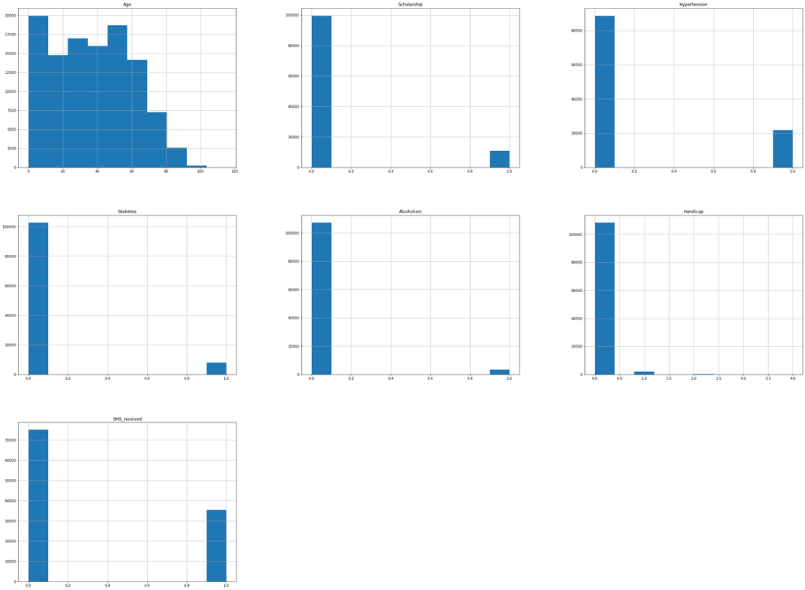

```python
data.hist(figsize=(40,30));
```

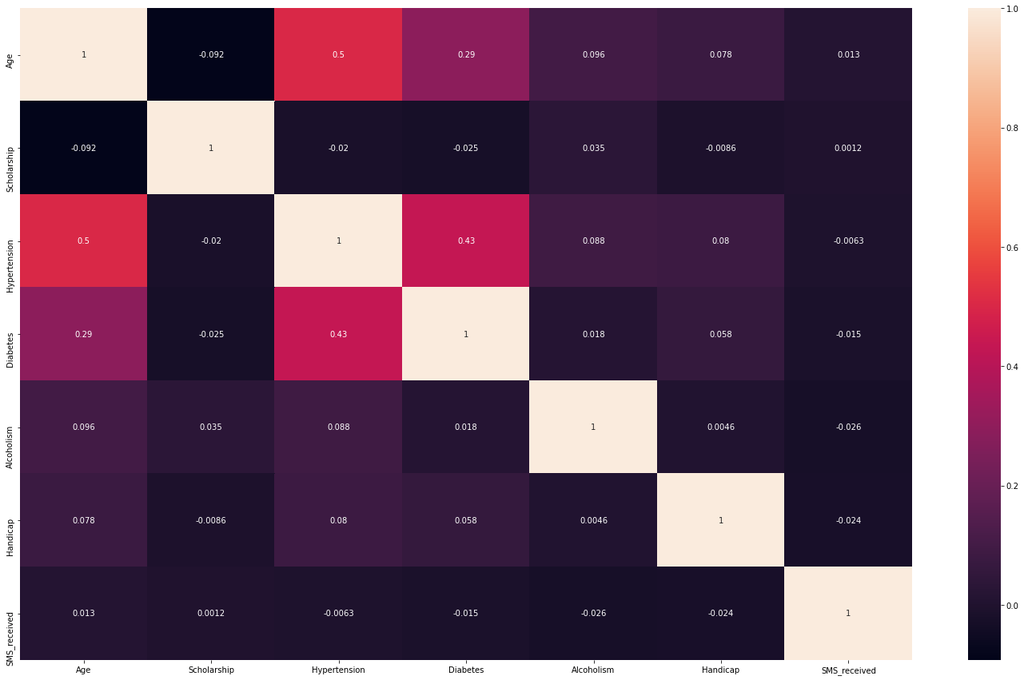

```python
#Heatmap Visualization to get an indication for which feature has a correlation with the other.
fig, ax = plt.subplots(figsize=(25,15))
sns.heatmap(data.corr(), ax=ax, annot=True);
```

**As we can see from the map above that the hypertension have a strong relation with age , aswell as a connection with diabetes, which is an already known logical observation**

- **So after this general analysis of the dataset ,Let us try to find a solution for the following questions**

# Questions

1. **What is the overall percentage of showing up on the appointment day with a relation to who didnt ?**
2. **Is the Gender associated with patient decision?**
3. **Does the age of the patient have any correlation to their decision?**
4. **Does the location of the hospital (Neighbourhood) affect the patient decision of coming to it on the scheduled date?**
5. **Does a certain feature (Scholarship , SMS-received) have an influence on the patient decision?**
6. **How is the patient decision does gets affected by their current health status? (any type of illness)**

```python
data
```

|  | Gender | ScheduledDay | AppointmentDay | Age | Neighbourhood | Scholarship | Hypertension | Diabetes | Alcoholism | Handicap | SMS_received | Attendance | Appointment_Day_Of_Week | Age_Group |
| --- | --- | --- | --- | --- | --- | --- | --- | --- | --- | --- | --- | --- | --- | --- |
| 0 | Female | 2016-04-29 | 2016-04-29 | 62 | JARDIM DA PENHA | 0 | 1 | 0 | 0 | 0 | 0 | Show | Friday | 47 -> 69 |
| 1 | Male | 2016-04-29 | 2016-04-29 | 56 | JARDIM DA PENHA | 0 | 0 | 0 | 0 | 0 | 0 | Show | Friday | 47 -> 69 |
| 2 | Female | 2016-04-29 | 2016-04-29 | 62 | MATA DA PRAIA | 0 | 0 | 0 | 0 | 0 | 0 | Show | Friday | 47 -> 69 |
| 3 | Female | 2016-04-29 | 2016-04-29 | 8 | PONTAL DE CAMBURI | 0 | 0 | 0 | 0 | 0 | 0 | Show | Friday | 0 -> 23 |
| 4 | Female | 2016-04-29 | 2016-04-29 | 56 | JARDIM DA PENHA | 0 | 1 | 1 | 0 | 0 | 0 | Show | Friday | 47 -> 69 |
| ... | ... | ... | ... | ... | ... | ... | ... | ... | ... | ... | ... | ... | ... | ... |
| 110522 | Female | 2016-05-03 | 2016-06-07 | 56 | MARIA ORTIZ | 0 | 0 | 0 | 0 | 0 | 1 | Show | Tuesday | 47 -> 69 |
| 110523 | Female | 2016-05-03 | 2016-06-07 | 51 | MARIA ORTIZ | 0 | 0 | 0 | 0 | 0 | 1 | Show | Tuesday | 47 -> 69 |
| 110524 | Female | 2016-04-27 | 2016-06-07 | 21 | MARIA ORTIZ | 0 | 0 | 0 | 0 | 0 | 1 | Show | Tuesday | 0 -> 23 |
| 110525 | Female | 2016-04-27 | 2016-06-07 | 38 | MARIA ORTIZ | 0 | 0 | 0 | 0 | 0 | 1 | Show | Tuesday | 24 -> 46 |
| 110526 | Female | 2016-04-27 | 2016-06-07 | 54 | MARIA ORTIZ | 0 | 0 | 0 | 0 | 0 | 1 | Show | Tuesday | 47 -> 69 |

110526 rows × 14 columns

## Definitions of Some Repetitive Functions

```python
#
#hue="Children" palette="plasma"
def Sns_Barcharts(Frame, Label,title):
    plt.figure(figsize=(7,7))
    ax = sns.countplot(x=Label, data=Frame)
    plt.xticks(rotation=-45)
    plt.title(title)
    #To show up the values of each bar.
    for p in ax.patches:
        ax.annotate(f'\n{p.get_height()}', (p.get_x()+0.2, p.get_height()), color='black', size=15)
    plt.show()
    return
```

```python
#
def Sns_BarchartsGroupby(Frame,G1,G2,title):
    plt.figure(figsize=(7,7))
    ax = sns.countplot(x=G2, data=Frame[G1])
    plt.xticks(rotation=-45)
    plt.title(title)
    #To show up the values of each bar.
    for p in ax.patches:
        ax.annotate(f'\n{p.get_height()}', (p.get_x()+0.2, p.get_height()), color='black', size=15)
    plt.show()
    return
```

```python
#
def Piecharts(Frame,Label,title):
    pie, ax = plt.subplots(figsize=[7,7])
    labels = Frame[Label].unique()
    plt.pie(x=Frame[Label].value_counts(), autopct="%1.2f%%", labels=labels, pctdistance=0.5)
    plt.title(title , fontsize=16)
    plt.show()
    return
```

```python
#
def PiechartsGrouby(Frame, G1 , G2 ,title ):
    pie, ax = plt.subplots(figsize=[7,7])
    labels = Frame[G1].unique()
    plt.pie(x=Frame[G1][G2].value_counts(), autopct="%1.2f%%", labels=labels, pctdistance=0.5)
    plt.title(title , fontsize=16)
    plt.show()
    return
```

## Research Question 1 :

**What is the overall percentage of showing up on the appointment day relative to who didnt ?**

```python
data
```

|  | Gender | ScheduledDay | AppointmentDay | Age | Neighbourhood | Scholarship | Hypertension | Diabetes | Alcoholism | Handicap | SMS_received | Attendance | Appointment_Day_Of_Week | Age_Group |
| --- | --- | --- | --- | --- | --- | --- | --- | --- | --- | --- | --- | --- | --- | --- |
| 0 | Female | 2016-04-29 | 2016-04-29 | 62 | JARDIM DA PENHA | 0 | 1 | 0 | 0 | 0 | 0 | Show | Friday | 47 -> 69 |
| 1 | Male | 2016-04-29 | 2016-04-29 | 56 | JARDIM DA PENHA | 0 | 0 | 0 | 0 | 0 | 0 | Show | Friday | 47 -> 69 |
| 2 | Female | 2016-04-29 | 2016-04-29 | 62 | MATA DA PRAIA | 0 | 0 | 0 | 0 | 0 | 0 | Show | Friday | 47 -> 69 |
| 3 | Female | 2016-04-29 | 2016-04-29 | 8 | PONTAL DE CAMBURI | 0 | 0 | 0 | 0 | 0 | 0 | Show | Friday | 0 -> 23 |
| 4 | Female | 2016-04-29 | 2016-04-29 | 56 | JARDIM DA PENHA | 0 | 1 | 1 | 0 | 0 | 0 | Show | Friday | 47 -> 69 |
| ... | ... | ... | ... | ... | ... | ... | ... | ... | ... | ... | ... | ... | ... | ... |
| 110522 | Female | 2016-05-03 | 2016-06-07 | 56 | MARIA ORTIZ | 0 | 0 | 0 | 0 | 0 | 1 | Show | Tuesday | 47 -> 69 |
| 110523 | Female | 2016-05-03 | 2016-06-07 | 51 | MARIA ORTIZ | 0 | 0 | 0 | 0 | 0 | 1 | Show | Tuesday | 47 -> 69 |
| 110524 | Female | 2016-04-27 | 2016-06-07 | 21 | MARIA ORTIZ | 0 | 0 | 0 | 0 | 0 | 1 | Show | Tuesday | 0 -> 23 |
| 110525 | Female | 2016-04-27 | 2016-06-07 | 38 | MARIA ORTIZ | 0 | 0 | 0 | 0 | 0 | 1 | Show | Tuesday | 24 -> 46 |
| 110526 | Female | 2016-04-27 | 2016-06-07 | 54 | MARIA ORTIZ | 0 | 0 | 0 | 0 | 0 | 1 | Show | Tuesday | 47 -> 69 |

110526 rows × 14 columns

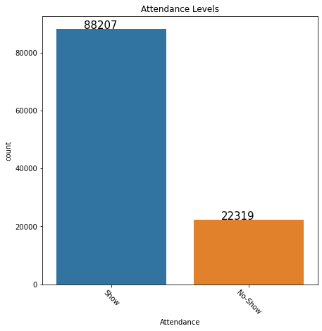

```python
#A Bar chart for the overall Ratios of Attendance Levels.
Sns_Barcharts(data,'Attendance', 'Attendance Levels')
```

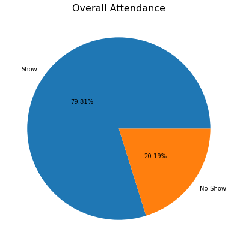

```python
Piecharts(data,'Attendance' ,'Overall Attendance')
```

```python
#Dividing the attendance values to 2 groups (Show , No-show)
Show=data.Attendance == 'Show'
No_Show= data.Attendance == 'No-Show'
```

**As we can see from the above charts 79.81% did show up on the appointment day they reserved while 20.19% didnt show up.**

## Research Question 2 :

**Is the Gender associated with the patient decision?**

```python
#Dividing the Gender values to 2 groups (Male , Female)
Male=data.Gender == 'Male'
Female= data.Gender == 'Female'
```

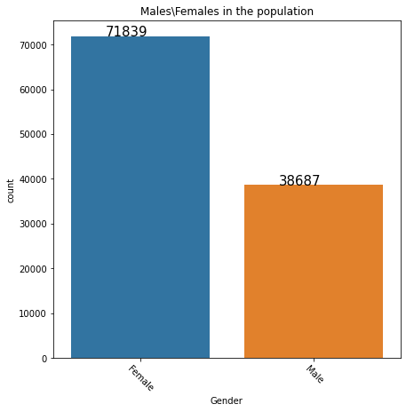

```python
#A Bar chart of Males\Females in the population
Sns_Barcharts(data,'Gender' ,'Males\Females in the population' )
```

**As we can see Females are much more than males in this dataset, Lets check up the percentages >>**

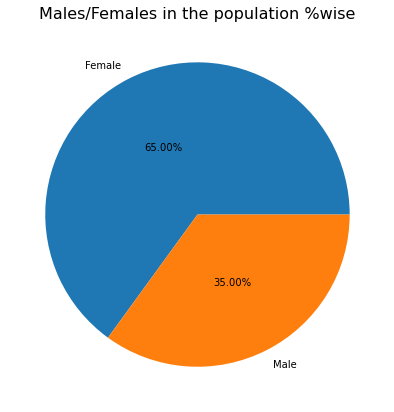

```python
Piecharts(data , 'Gender' , 'Males/Females in the population %wise')
```

**Its now clear with numbers that females are 65% of total population of this dataset**

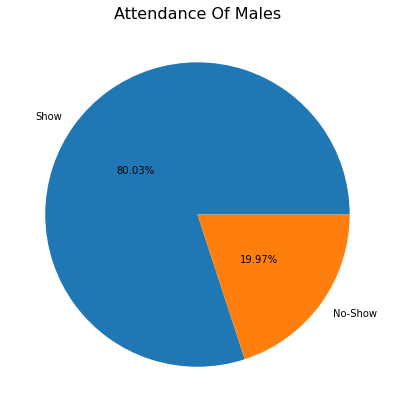

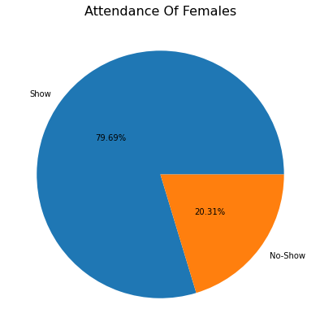

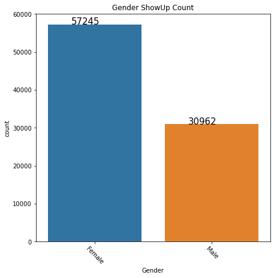

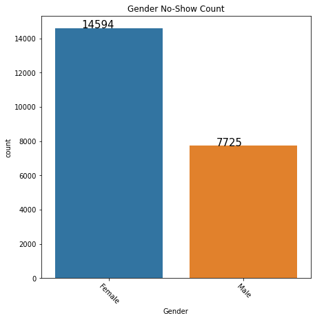

```python
#lets check the correlation between gender and attendance rates.
#Percentages between Males/Females who did show up
PiechartsGrouby(data ,'Attendance',Male,"Attendance Of Males")
PiechartsGrouby(data ,'Attendance',Female,"Attendance Of Females")
Sns_BarchartsGroupby(data,'Gender',Show,"Gender ShowUp Count")
Sns_BarchartsGroupby(data,'Gender',No_Show,"Gender No-Show Count")
```

**From the pie chart above we can conclude the following** :

- **`males showup rate 80.04% and females showup rate is 79.69% ,Also Males rate of Not showing up 19.96% and the corresponding rate for females is 20.31%`**
- **`Males rate of Not showing up 19.96% and the corresponding rate for females is 20.31%`**

So we need further exploration in this topic to determine which gender shows up more, **Lets try to calculate the actual Numbers which are shown in the par charts above**

```python
#Number of males who did showup in the dataset
number_males=data['Gender'] == 'Male'
print('The Number of total males in dataset' , number_males.sum())
number_males_showup=number_males.sum() * (80.04/100)
print('The Number of whom did showup approx > ' , int(number_males_showup) , 'Male Patients')
print('The Number of whom didnt showup approx > ' , int(number_males.sum()-number_males_showup) , 'Male Patients')
```

```
The Number of total males in dataset 38687
The Number of whom did showup approx >  30965 Male Patients
The Number of whom didnt showup approx >  7721 Male Patients
```

```python
#Number of Females who did showup in the dataset
number_females=data['Gender'] == 'Female'
print('The Number of total Female in dataset' , number_females.sum())
number_females_showup=number_females.sum() * (79.69/100)
print('The Number of whom did showup approx > ' , int(number_females_showup) , 'Female Patients')
print('The Number of whom didnt showup approx > ' , int(number_females.sum()-number_females_showup) , 'Female Patients')
```

```
The Number of total Female in dataset 71839
The Number of whom did showup approx >  57248 Female Patients
The Number of whom didnt showup approx >  14590 Female Patients
```

So according to the statistics above we can conclude that Males & Females have nearly the same show up rates,**Hence the decision of the patient isnt related to their gender.**

## Research Question 3 :

Does the location **(Neighbourhood)** of the hospital affect the patient decision of showing up on the scheduled date?

We already have a dataset which includes the top 10 visited Neighbourhood in this dataset and they are as follows :

```python
Most_Visited_Neighbourhood_dataset.Neighbourhood.unique()
```

```
array(['JARDIM DA PENHA', 'TABUAZEIRO', 'SANTA MARTHA', 'BONFIM',
       'JARDIM CAMBURI', 'MARIA ORTIZ', 'RESISTÊNCIA', 'ITARARÉ',
       'CENTRO', 'JESUS DE NAZARETH'], dtype=object)
```

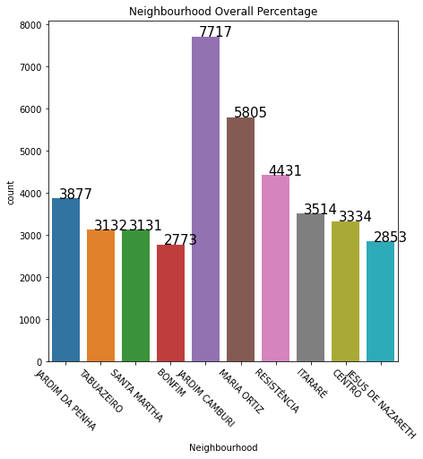

```python
Sns_Barcharts(Most_Visited_Neighbourhood_dataset  ,'Neighbourhood' ,"Neighbourhood Overall Percentage")
```

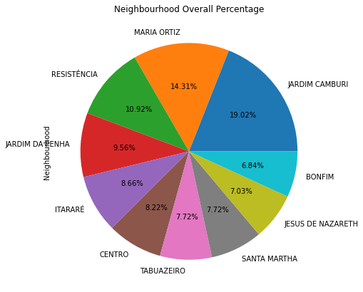

```python
Most_Visited_Neighbourhood_dataset['Neighbourhood'].value_counts().plot(figsize=(7,7) ,kind = 'pie' , autopct='%1.2f%%');
plt.title("Neighbourhood Overall Percentage" , fontweight=25);
```

The most visited Neighbourhood is **JARDIM CAMBURI** which is 19.02% & least visited is **BONFIM** with 6.84%,as we can see from the above chart,We cant actually determine the actual impact of location of the hospital since we dont have an informations about where the patients live in.

**But we can check if they there is any correlation between Neighbourhood & Attendance**

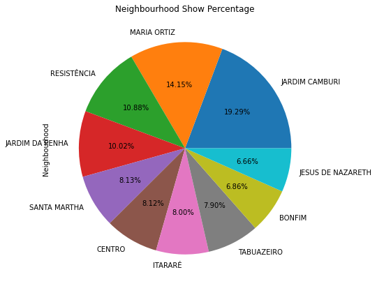

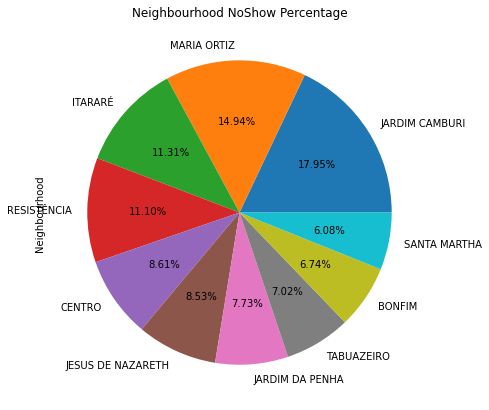

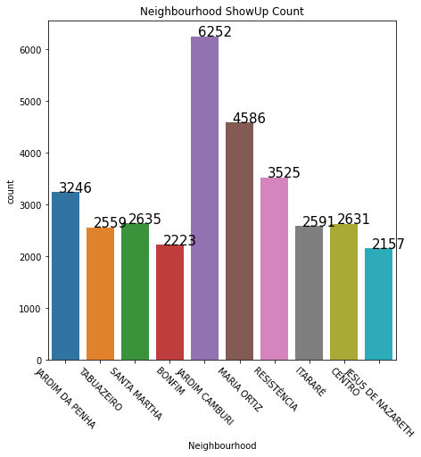

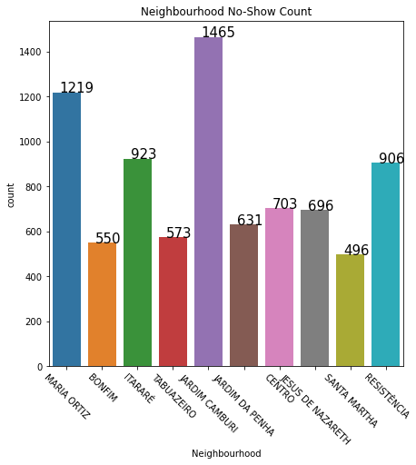

```python
#We can have a visualization for the different Show up rates for these top 10 Neighbourhoods.
Most_Visited_Neighbourhood_dataset_Show['Neighbourhood'].value_counts().plot(figsize=(7,7) ,kind = 'pie' , autopct='%1.2f%%');
plt.title("Neighbourhood Show Percentage" , fontweight=25);
plt.show()
Most_Visited_Neighbourhood_dataset_NoShow['Neighbourhood'].value_counts().plot(figsize=(7,7) ,kind = 'pie' , autopct='%1.2f%%');
plt.title("Neighbourhood NoShow Percentage" , fontweight=25);
plt.show()
Sns_Barcharts(Most_Visited_Neighbourhood_dataset_Show , 'Neighbourhood' ,"Neighbourhood ShowUp Count")
Sns_Barcharts(Most_Visited_Neighbourhood_dataset_NoShow , 'Neighbourhood' ,"Neighbourhood No-Show Count")
```

**So its clear that Neighbourhoods Does have an impact on the patients ShowUp Rates.**

## Research Question 4 :

**Does the age of the patient have any correlation to their decision?**

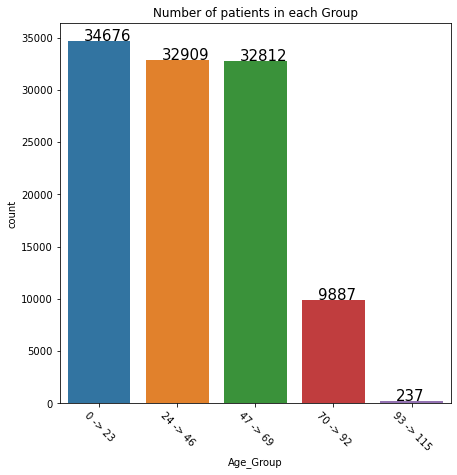

```python
#We already divided the population to a different groups so we can have a visualization for it.
Sns_Barcharts(data , 'Age_Group','Number of patients in each Group')
```

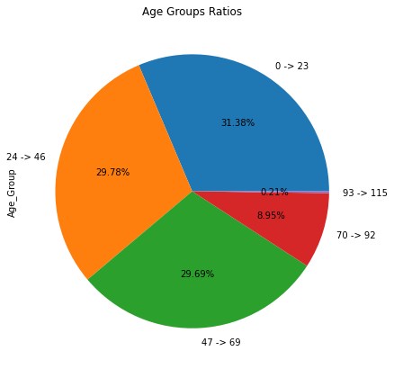

```python
piechart_Age = data.Age_Group.value_counts().plot(figsize=(7,7) ,kind = 'pie' ,autopct='%1.2f%%');
plt.title("Age Groups Ratios" , fontweight=25);
```

As we can see from the above chart the age group **range of 0 to 23** have a total percentage of the population is **31.37%** meanwhile least amount is for age group **93 to 115** which is **0.21%**

As we can see we have 5 different groups, lets us check the statistics for the showUp rates

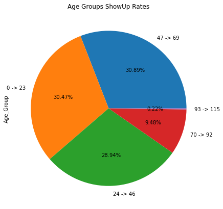

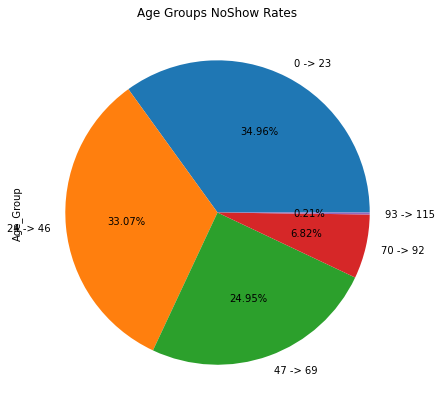

```python
#The Relation between Show up rates with respect to Different age groups
piechart_Age = data.Age_Group[Show].value_counts().plot(figsize=(7,7) ,kind = 'pie' ,autopct='%1.2f%%');
plt.title("Age Groups ShowUp Rates" , fontweight=25);
plt.show()
piechart_Age = data.Age_Group[No_Show].value_counts().plot(figsize=(7,7) ,kind = 'pie' ,autopct='%1.2f%%');
plt.title("Age Groups NoShow Rates" , fontweight=25);
plt.show()
```

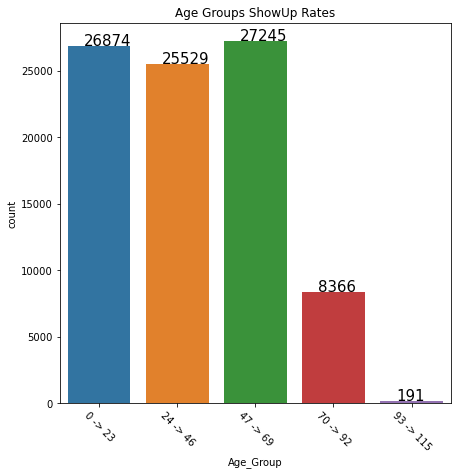

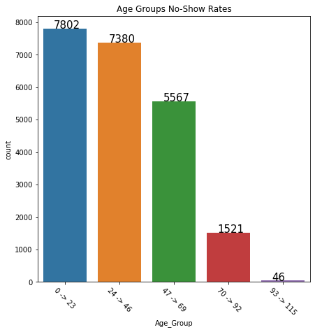

```python
#Bar Chart for ShowUp rates
Sns_BarchartsGroupby(data , 'Age_Group'  ,Show , "Age Groups ShowUp Rates")
Sns_BarchartsGroupby(data , 'Age_Group'  ,No_Show , "Age Groups No-Show Rates")
```

- **So for us to get a more clear overview of the effect of the age on the patient attendance we need a more deep analysis of each group age population levels and their corrisponding Showup rates.**

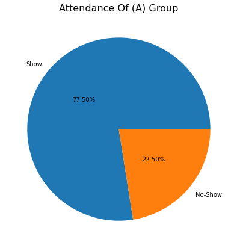

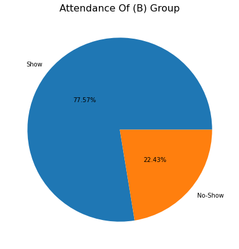

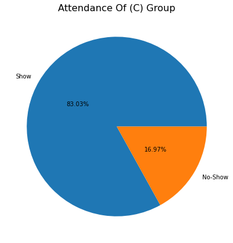

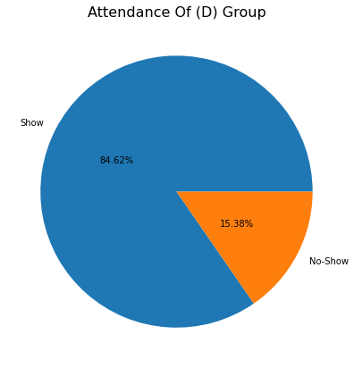

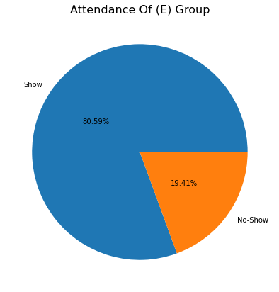

```python
#A ---> 0 TO 23
#B ---> 24 TO 46
#C ---> 47 TO 69
#D ---> 70 TO 92
#E ---> 93 TO 115
A=data['Age_Group'] == '0 -> 23'
B=data['Age_Group'] == '24 -> 46'
C=data['Age_Group'] == '47 -> 69'
D=data['Age_Group'] == '70 -> 92'
E=data['Age_Group'] == '93 -> 115'
#Now lets plot a pie chart for each age group with respect to the Show rate.
PiechartsGrouby(data,'Attendance' , A,"Attendance Of (A) Group")
PiechartsGrouby(data,'Attendance' , B,"Attendance Of (B) Group")
PiechartsGrouby(data,'Attendance' , C,"Attendance Of (C) Group")
PiechartsGrouby(data,'Attendance' , D,"Attendance Of (D) Group")
PiechartsGrouby(data,'Attendance' , E,"Attendance Of (E) Group")
```

```python
#each group numbers of patient in it.(True count)
fc1, tc1 = A.value_counts().sort_index().tolist()
fc2, tc2 = B.value_counts().sort_index().tolist()
fc3, tc3 = C.value_counts().sort_index().tolist()
fc4, tc4 = D.value_counts().sort_index().tolist()
fc5, tc5 = E.value_counts().sort_index().tolist()
print('Group A numbers are => ' , tc1  ,'Patient.')
print('Group B numbers are => ' , tc2  ,'Patient.')
print('Group C numbers are => ' , tc3  ,'Patient.')
print('Group D numbers are => ' , tc4  ,'Patient.')
print('Group E numbers are => ' , tc5  ,'Patient.')
```

```
Group A numbers are =>  34676 Patient.
Group B numbers are =>  32909 Patient.
Group C numbers are =>  32812 Patient.
Group D numbers are =>  9887 Patient.
Group E numbers are =>  237 Patient.
```

In conclusion of the above charts and statistics we can say that :

- **Group D has the highest show up rates with 84.62% which is the range from 70 to 92**
- **Group A has the Lowest show up rates with 77.51% which is the range from 0 to 23**

**So its clear that older people with range of 70 to 92 tend to show up on their appointment day, and by that we can see that Age does play a factor in ShowUp rates of the patients.**